# CENG 4515 DATA SCIENCE AND ANALYTICS

HOMEWORK - 1

Ayşe Ceren Çiçek

Dataset: https://www.kaggle.com/sootersaalu/amazon-top-50-bestselling-books-2009-2019

The dataset is Amazon’s Top 50 bestselling books from 2009 to 2019 from Kaggle. Contains 550 rows and 7 columns, books have been categorized into fiction and non-fiction. Column informations are listed down below:

- Name: Name of the book
- Author: The author of the book
- User Rating: Amazon user rating
- Reviews: Number of written reviews on Amazon
- Price: The price of the book (As at 13/10/2020)
- Year: The year(s) it ranked on the bestseller
- Genre: Whether fiction or non-fiction

## Importing libraries

```r
library(tidyverse)
library(plyr)
library(ggplot2)
```

## Loading dataset

```r
# Load dataset
dataset <- read.csv('/Users/cerencicek/Documents/School/2-Data Science/Homework/bestselling_books.csv')

# Show first 5 columns of the data
head(dataset, n=5)
```

```
##                                                                 Name
## 1                                      10-Day Green Smoothie Cleanse
## 2                                                  11/22/63: A Novel
## 3                            12 Rules for Life: An Antidote to Chaos
## 4                                             1984 (Signet Classics)
## 5 5,000 Awesome Facts (About Everything!) (National Geographic Kids)
##                     Author User.Rating Reviews Price Year       Genre
## 1                 JJ Smith         4.7   17350     8 2016 Non Fiction
## 2             Stephen King         4.6    2052    22 2011     Fiction
## 3       Jordan B. Peterson         4.7   18979    15 2018 Non Fiction
## 4            George Orwell         4.7   21424     6 2017     Fiction
## 5 National Geographic Kids         4.8    7665    12 2019 Non Fiction
```

# Data preprocessing

Let’s summarize our data.

```r
summary(dataset)
```

```
##      Name              Author           User.Rating       Reviews
##  Length:550         Length:550         Min.   :3.300   Min.   :   37
##  Class :character   Class :character   1st Qu.:4.500   1st Qu.: 4058
##  Mode  :character   Mode  :character   Median :4.700   Median : 8580
##                                        Mean   :4.618   Mean   :11953
##                                        3rd Qu.:4.800   3rd Qu.:17253
##                                        Max.   :4.900   Max.   :87841
##      Price            Year         Genre
##  Min.   :  0.0   Min.   :2009   Length:550
##  1st Qu.:  7.0   1st Qu.:2011   Class :character
##  Median : 11.0   Median :2014   Mode  :character
##  Mean   : 13.1   Mean   :2014
##  3rd Qu.: 16.0   3rd Qu.:2017
##  Max.   :105.0   Max.   :2019
```

As seen above the data types of Name and Author columns are Character. To get more accurate information about the data types of the rest of the columns, we can use sapply function. The sapply function is a vectorized function that allows you to iterate over a list or vector without the need of using the for loop. The below code shows the data types of each column.

```r
sapply(dataset, class)
```

```
##        Name      Author User.Rating     Reviews       Price        Year
## "character" "character"   "numeric"   "integer"   "integer"   "integer"
##       Genre
## "character"
```

The data type of the Genre column is character but it contains categorical data. We can use as.factor function to turn it into factor.

```r
dataset <- transform(dataset, Genre = as.factor(mapvalues(Genre,c("Non Fiction","Fiction"), c("Non-Fiction", "Fiction"))))
summary(dataset)
```

```
##      Name              Author           User.Rating       Reviews
##  Length:550         Length:550         Min.   :3.300   Min.   :   37
##  Class :character   Class :character   1st Qu.:4.500   1st Qu.: 4058
##  Mode  :character   Mode  :character   Median :4.700   Median : 8580
##                                        Mean   :4.618   Mean   :11953
##                                        3rd Qu.:4.800   3rd Qu.:17253
##                                        Max.   :4.900   Max.   :87841
##      Price            Year              Genre
##  Min.   :  0.0   Min.   :2009   Fiction    :240
##  1st Qu.:  7.0   1st Qu.:2011   Non-Fiction:310
##  Median : 11.0   Median :2014
##  Mean   : 13.1   Mean   :2014
##  3rd Qu.: 16.0   3rd Qu.:2017
##  Max.   :105.0   Max.   :2019
```

Now our Genre column turn into factor which contains two categories, Fiction and Non-Fiction.

```r
sapply(dataset, class)
```

```
##        Name      Author User.Rating     Reviews       Price        Year
## "character" "character"   "numeric"   "integer"   "integer"   "integer"
##       Genre
##    "factor"
```

## Data Transformation

### Filter

The filter() function is used to subset a data frame, retaining all rows that satisfy conditions. We can reach the books of an author. For example, the below code’s output shows the books of George Orwell from our data.

```r
filter(dataset, Author == 'George Orwell')
```

```
##                     Name        Author User.Rating Reviews Price Year   Genre
## 1 1984 (Signet Classics) George Orwell         4.7   21424     6 2017 Fiction
```

We can filter books by their name.

```r
filter(dataset, Name == 'A Man Called Ove: A Novel')
```

```
##                        Name          Author User.Rating Reviews Price Year
## 1 A Man Called Ove: A Novel Fredrik Backman         4.6   23848     8 2016
## 2 A Man Called Ove: A Novel Fredrik Backman         4.6   23848     8 2017
##     Genre
## 1 Fiction
## 2 Fiction
```

We can also use the filter function with more than one condition. Let’s get the bestseller fiction books of 2012 which has ratings greater than 4.5

```r
filter(dataset, User.Rating > 4.5, Genre == 'Fiction', Year == 2012)
```

```
##                                                                                                 Name
## 1                                                                   Catching Fire (The Hunger Games)
## 2  Game of Thrones Boxed Set: A Game of Thrones/A Clash of Kings/A Storm of Swords/A Feast for Crows
## 3    Goodnight, Goodnight Construction Site (Hardcover Books for Toddlers, Preschool Books for Kids)
## 4                                                                          Oh, the Places You'll Go!
## 5                                                                             The Fault in Our Stars
## 6                       The Harbinger: The Ancient Mystery that Holds the Secret of America's Future
## 7                                                                          The Hunger Games (Book 1)
## 8                                                             The Hunger Games Trilogy Boxed Set (1)
## 9                                                     The Mark of Athena (Heroes of Olympus, Book 3)
## 10                                                The Serpent's Shadow (The Kane Chronicles, Book 3)
## 11                                                    The Third Wheel (Diary of a Wimpy Kid, Book 7)
##                  Author User.Rating Reviews Price Year   Genre
## 1       Suzanne Collins         4.7   22614    11 2012 Fiction
## 2    George R.R. Martin         4.6    5594     5 2012 Fiction
## 3  Sherri Duskey Rinker         4.9    7038     7 2012 Fiction
## 4             Dr. Seuss         4.9   21834     8 2012 Fiction
## 5            John Green         4.7   50482    13 2012 Fiction
## 6         Jonathan Cahn         4.6   11098    13 2012 Fiction
## 7       Suzanne Collins         4.7   32122     8 2012 Fiction
## 8       Suzanne Collins         4.8   16949    30 2012 Fiction
## 9          Rick Riordan         4.8    6247    10 2012 Fiction
## 10         Rick Riordan         4.8    2091    12 2012 Fiction
## 11          Jeff Kinney         4.7    6377     7 2012 Fiction
```

We can also use the | (or) and & (and) operator to define an interval.

```r
filter(dataset, User.Rating > 4.5 & User.Rating < 4.8 , Year == 2015)
```

```
##                                                                                                                         Name
## 1                                                                       Adult Coloring Book: Stress Relieving Animal Designs
## 2                                                                                                All the Light We Cannot See
## 3                                      American Sniper: The Autobiography of the Most Lethal Sniper in U.S. Military History
## 4                                                                                               Baby Touch and Feel: Animals
## 5                                                                                   Balance (Angie's Extreme Stress Menders)
## 6                                                                                                   Between the World and Me
## 7                              Dover Creative Haven Art Nouveau Animal Designs Coloring Book (Creative Haven Coloring Books)
## 8  Enchanted Forest: An Inky Quest and Coloring book (Activity Books, Mindfulness and Meditation, Illustrated Floral Prints…
## 9                                                                                                            First 100 Words
## 10                                                                                                Harry Potter Coloring Book
## 11                                                                                     How to Win Friends & Influence People
## 12                            Killing Reagan: The Violent Assault That Changed a Presidency (Bill O'Reilly's Killing Series)
## 13                                                                                             Laugh-Out-Loud Jokes for Kids
## 14                                                                                    Mindset: The New Psychology of Success
```

[output cut: 31 more lines]

### Arrange

The arrange function orders rows by variables.

In the example down below, we sorted rows by Year, Price, and User Rating columns.

```r
dataset <- arrange(dataset, Year, Price, User.Rating)
head(dataset)
```

```
##                                                                              Name
## 1 Eat This Not That! Supermarket Survival Guide: The No-Diet Weight Loss Solution
## 2                             The Girl with the Dragon Tattoo (Millennium Series)
## 3         Dead And Gone: A Sookie Stackhouse Novel (Sookie Stackhouse/True Blood)
## 4                                               Have a Little Faith: A True Story
## 5                 Arguing with Idiots: How to Stop Small Minds and Big Government
## 6                                                        The Time Traveler's Wife
##               Author User.Rating Reviews Price Year       Genre
## 1    David Zinczenko         4.5     720     1 2009 Non-Fiction
## 2      Stieg Larsson         4.4   10559     2 2009     Fiction
## 3   Charlaine Harris         4.6    1541     4 2009     Fiction
## 4        Mitch Albom         4.8    1930     4 2009 Non-Fiction
## 5         Glenn Beck         4.6     798     5 2009 Non-Fiction
## 6 Audrey Niffenegger         4.4    3759     6 2009     Fiction
```

We can also sort the values in descending order.

```r
head(arrange(dataset, desc(User.Rating)))
```

```
##                                                                                              Name
## 1                       Jesus Calling: Enjoying Peace in His Presence (with Scripture References)
## 2 Goodnight, Goodnight Construction Site (Hardcover Books for Toddlers, Preschool Books for Kids)
## 3                       Jesus Calling: Enjoying Peace in His Presence (with Scripture References)
## 4                                                                       Oh, the Places You'll Go!
## 5                                                                     The Very Hungry Caterpillar
## 6 Goodnight, Goodnight Construction Site (Hardcover Books for Toddlers, Preschool Books for Kids)
##                 Author User.Rating Reviews Price Year       Genre
## 1          Sarah Young         4.9   19576     8 2011 Non-Fiction
## 2 Sherri Duskey Rinker         4.9    7038     7 2012     Fiction
## 3          Sarah Young         4.9   19576     8 2012 Non-Fiction
## 4            Dr. Seuss         4.9   21834     8 2012     Fiction
## 5           Eric Carle         4.9   19546     5 2013     Fiction
## 6 Sherri Duskey Rinker         4.9    7038     7 2013     Fiction
```

### Select

The select function only keeps the variables we mention. The below code returns data with 4 columns.

```r
head(select(dataset, Name, Author, User.Rating, Year))
```

```
##                                                                              Name
## 1 Eat This Not That! Supermarket Survival Guide: The No-Diet Weight Loss Solution
## 2                             The Girl with the Dragon Tattoo (Millennium Series)
## 3         Dead And Gone: A Sookie Stackhouse Novel (Sookie Stackhouse/True Blood)
## 4                                               Have a Little Faith: A True Story
## 5                 Arguing with Idiots: How to Stop Small Minds and Big Government
## 6                                                        The Time Traveler's Wife
##               Author User.Rating Year
## 1    David Zinczenko         4.5 2009
## 2      Stieg Larsson         4.4 2009
## 3   Charlaine Harris         4.6 2009
## 4        Mitch Albom         4.8 2009
## 5         Glenn Beck         4.6 2009
## 6 Audrey Niffenegger         4.4 2009
```

We can take out a subset of columns using hyphen (-) and colon (:).

```r
head(select(dataset, -(Reviews:Price)))
```

```
##                                                                              Name
## 1 Eat This Not That! Supermarket Survival Guide: The No-Diet Weight Loss Solution
## 2                             The Girl with the Dragon Tattoo (Millennium Series)
## 3         Dead And Gone: A Sookie Stackhouse Novel (Sookie Stackhouse/True Blood)
## 4                                               Have a Little Faith: A True Story
## 5                 Arguing with Idiots: How to Stop Small Minds and Big Government
## 6                                                        The Time Traveler's Wife
##               Author User.Rating Year       Genre
## 1    David Zinczenko         4.5 2009 Non-Fiction
## 2      Stieg Larsson         4.4 2009     Fiction
## 3   Charlaine Harris         4.6 2009     Fiction
## 4        Mitch Albom         4.8 2009 Non-Fiction
## 5         Glenn Beck         4.6 2009 Non-Fiction
## 6 Audrey Niffenegger         4.4 2009     Fiction
```

```r
head(select(dataset, User.Rating, Year, Author, everything()))
```

```
##   User.Rating Year             Author
## 1         4.5 2009    David Zinczenko
## 2         4.4 2009      Stieg Larsson
## 3         4.6 2009   Charlaine Harris
## 4         4.8 2009        Mitch Albom
## 5         4.6 2009         Glenn Beck
## 6         4.4 2009 Audrey Niffenegger
##                                                                              Name
## 1 Eat This Not That! Supermarket Survival Guide: The No-Diet Weight Loss Solution
## 2                             The Girl with the Dragon Tattoo (Millennium Series)
## 3         Dead And Gone: A Sookie Stackhouse Novel (Sookie Stackhouse/True Blood)
## 4                                               Have a Little Faith: A True Story
## 5                 Arguing with Idiots: How to Stop Small Minds and Big Government
## 6                                                        The Time Traveler's Wife
##   Reviews Price       Genre
## 1     720     1 Non-Fiction
## 2   10559     2     Fiction
## 3    1541     4     Fiction
## 4    1930     4 Non-Fiction
## 5     798     5 Non-Fiction
## 6    3759     6     Fiction
```

## Data Visualization

The below plot displays the number of books based on their genres using a bar chart.The bestseller books are more in the non-fiction category.

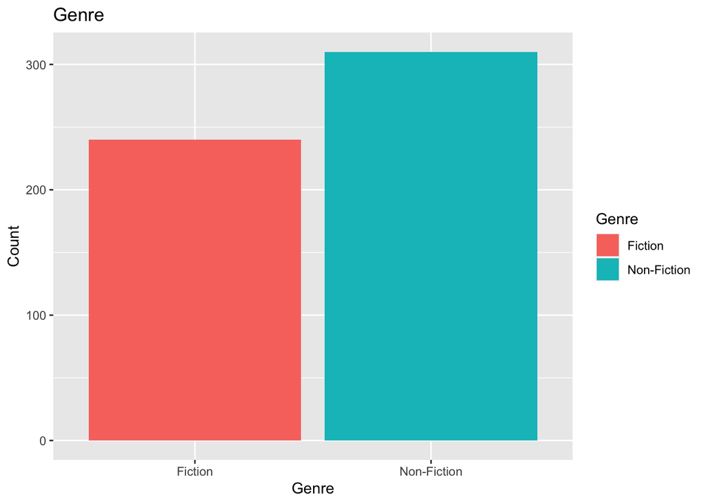

```r
ggplot(dataset, aes(x=Genre, fill=Genre))+
  geom_bar() + labs(title = "Genre", x="Genre", y="Count")
```

Let’s visualize user ratings of books based on their genre with box plot. It seems that fiction books got a bit higher ratings from users than non-fiction books.

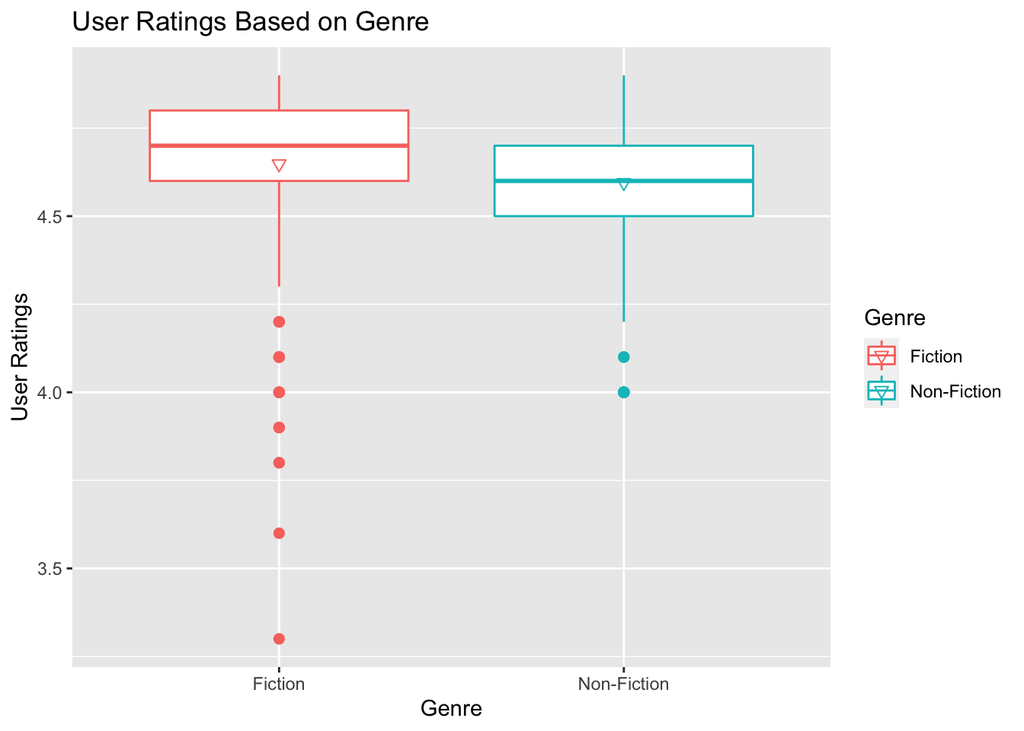

```r
ggplot(dataset, aes(x=Genre, y=User.Rating, color= Genre)) +
  geom_boxplot(outlier.size=2) + stat_summary(fun=mean, geom="point", shape=6, size=2) +
  labs(title = "User Ratings Based on Genre",x= "Genre",y= "User Ratings")
```

To display the total number of books by their category based on years, we should turn year to factor. In 2015, more non-fiction books looks in bestsellers, and in 2014 it is vice versa.

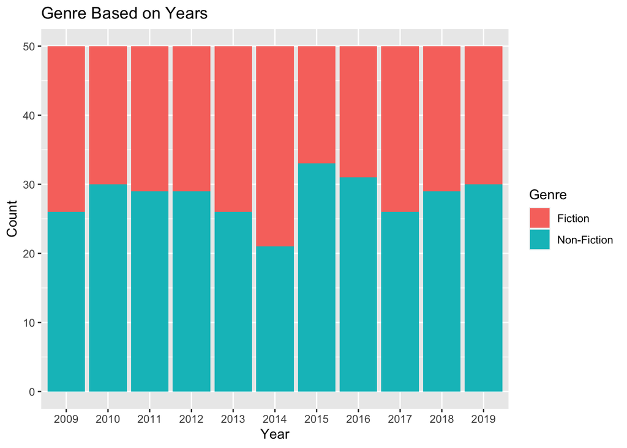

```r
dataset$Year.Factor <- as.factor(dataset$Year)
ggplot(dataset, aes(x=Year.Factor, fill=Genre))+
  geom_bar() +
  labs(title = "Genre Based on Years",x= "Year",y= "Count")
```

The below plot shows the relation between the number of reviews and the price based on genre.

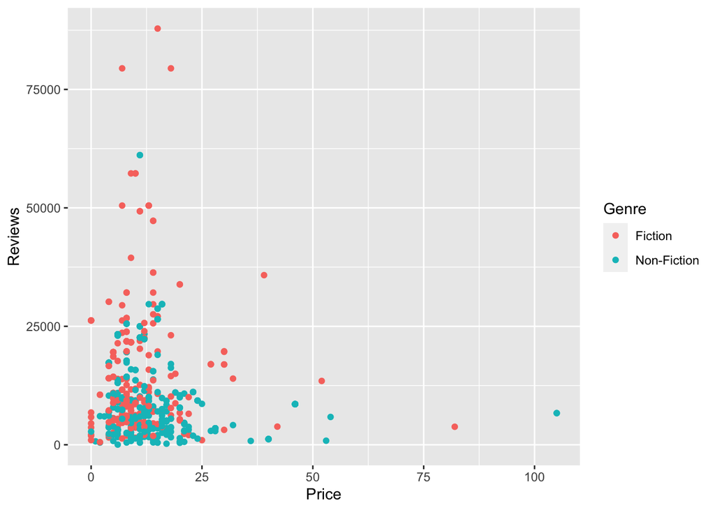

```r
ggplot(data = dataset) +
  geom_point(mapping = aes(x = Price, y = Reviews, color=Genre))
```